# Eksplorasi dan visualisasi data rental film di negara ASEAN berdasarkan database sakila

2026-05-26

# Pendahuluan

Dataset Sakila merupakan data contoh sistem rental film yang mencakup informasi mengenai pelanggan, transaksi rental, film, genre, wilayah (negara), serta pendapatan (amount). Saya mengambil insight dari dataset ini untuk menganalisis pola konsumsi film di kawasan ASEAN berdasarkan jumlah rental, preferensi genre, serta kontribusi pendapatan.

### Insight yang diambil

1. Film apa saja yang termasuk dalam Top 5 film terlaris berdasarkan jumlah rental di negara-negara ASEAN?
2. Bagaimana distribusi genre film yang paling banyak diminati oleh pelanggan di kawasan ASEAN?
3. Bagaimana performa toko (store) di wilayah ASEAN berdasarkan jumlah pelanggan, jumlah transaksi, dan market share (kontribusi) masing-masing negara ASEAN terhadap total rental film?
4. Bagaimana jumlah pendapatan dari setiap negara di ASEAN

# Gambar Peta ASEAN

### Berikut adalah gambar peta negara ASEAN

[figure not shown]

# Metode Analisis

### Persiapan dan koneksi data

```r
# Persiapan dan import data
library(DBI)
library(odbc)
library(dplyr)
```

```r
library(ggplot2)
library(RMySQL)
library(knitr)
con2 = dbConnect(odbc(),
                 Driver = "MySQL ODBC 8.0 ANSI Driver",
                 SERVER = "127.0.0.1",
                 UID = "root",
                 PWD = "tata230207",
                 Port = 3306,
                 database = "sakila")
dbIsValid(con2)
```

```
## [1] TRUE
```

### Sintaks yang digunakan untuk melihat film yang paling diminati di negara ASEAN

```r
datafilm = dbGetQuery(con2,"SELECT f.title AS judul_film, COUNT(r.rental_id) AS total_rental
FROM country co
JOIN city ci ON co.country_id = ci.country_id
JOIN address a ON ci.city_id = a.city_id
JOIN customer c ON a.address_id = c.address_id
JOIN rental r ON c.customer_id = r.customer_id
JOIN inventory i ON r.inventory_id = i.inventory_id
JOIN film f ON i.film_id = f.film_id
WHERE co.country IN (
'Indonesia','Malaysia','Singapore',
'Thailand','Philippines','Vietnam',
'Brunei','Cambodia','Laos','Myanmar')
GROUP BY f.title
ORDER BY total_rental DESC")
top5 <- head(datafilm, 5)
print(top5)
```

```
##            judul_film total_rental
## 1  STRANGELOVE DESIRE            7
## 2     SUSPECTS QUILLS            6
## 3 OPERATION OPERATION            6
## 4        HORN WORKING            6
## 5     CROOKED FROGMEN            6
```

### Sintaks yang digunakan untuk melihat genre favorite dari negara ASEAN

```r
datagenre = dbGetQuery(con2, "SELECT cat.name AS Genre, COUNT(r.rental_id) AS Total_Rental
FROM country co
JOIN city ci ON co.country_id = ci.country_id
JOIN address a ON ci.city_id = a.city_id
JOIN customer c ON a.address_id = c.address_id
JOIN rental r ON c.customer_id = r.customer_id
JOIN inventory i ON r.inventory_id = i.inventory_id
JOIN film_category f ON i.film_id = f.film_id
JOIN category cat ON f.category_id = cat.category_id
WHERE co.country IN (
'Indonesia','Malaysia','Singapore',
'Thailand','Philippines','Vietnam',
'Brunei','Cambodia','Laos','Myanmar')
GROUP BY Genre
ORDER BY Total_Rental DESC")
print(datagenre)
```

```
##          Genre Total_Rental
## 1    Animation          113
## 2      Foreign          102
## 3       Family          100
## 4       Action           99
## 5        Drama           96
## 6       Sports           95
## 7       Comedy           91
## 8        Games           86
## 9       Sci-Fi           86
## 10         New           84
## 11    Children           84
## 12      Travel           80
## 13       Music           79
## 14 Documentary           79
## 15    Classics           78
## 16      Horror           76
```

### Sintaks untuk melihat performa toko di wilayah ASEAN

```r
con2 = dbConnect(odbc(),
                 Driver = "MySQL ODBC 8.0 ANSI Driver",
                 SERVER = "127.0.0.1",
                 UID = "root",
                 PWD = "tata230207",
                 Port = 3306,
                 database = "sakila")
tabelperforma = dbGetQuery(con2, "SELECT co.country, COUNT(DISTINCT cu.customer_id) AS jumlah_pelanggan,
COUNT(r.rental_id) AS jumlah_transaksi,
ROUND(COUNT(r.rental_id) * 1.0 / COUNT(DISTINCT cu.customer_id), 2) AS rata_transaksi_per_pelanggan,
CONCAT(ROUND(COUNT(r.rental_id) * 100.0 / SUM(COUNT(r.rental_id)) OVER(), 2), '%') AS market_share
FROM country co
JOIN city ci ON co.country_id = ci.country_id
JOIN address a ON ci.city_id = a.city_id
JOIN customer cu ON a.address_id = cu.address_id
JOIN rental r ON cu.customer_id = r.customer_id
WHERE co.country IN (
    'Indonesia','Malaysia','Singapore',
    'Thailand','Philippines','Vietnam',
    'Brunei','Cambodia','Laos','Myanmar'
)
GROUP BY co.country
ORDER BY jumlah_transaksi DESC")
print(tabelperforma)
```

```
##       country jumlah_pelanggan jumlah_transaksi rata_transaksi_per_pelanggan
## 1 Philippines               20              568                        28.40
## 2   Indonesia               14              367                        26.21
## 3     Vietnam                6              172                        28.67
## 4    Thailand                3               96                        32.00
## 5    Malaysia                3               85                        28.33
## 6    Cambodia                2               53                        26.50
## 7     Myanmar                2               52                        26.00
## 8      Brunei                1               35                        35.00
##   market_share
## 1       39.78%
## 2       25.70%
## 3       12.04%
## 4        6.72%
## 5        5.95%
## 6        3.71%
## 7        3.64%
## 8        2.45%
```

### Sintaks untuk melihat total pendapatan setiap negara di wilayah ASEAN

```r
datapendapatan = dbGetQuery(con2,"SELECT co.country, SUM(p.amount) AS total_Pendapatan
FROM country co
JOIN city ci ON co.country_id = ci.country_id
JOIN address a ON ci.city_id = a.city_id
JOIN customer c ON a.address_id = c.address_id
JOIN payment p ON c.customer_id = p.customer_id
WHERE co.country IN (
  'Indonesia','Malaysia','Singapore',
  'Thailand','Philippines','Vietnam',
  'Brunei','Cambodia','Laos','Myanmar'
)
GROUP BY co.country
ORDER BY total_Pendapatan DESC")
print(datapendapatan)
```

```
##       country total_Pendapatan
## 1 Philippines          2381.32
## 2   Indonesia          1510.33
## 3     Vietnam           746.28
## 4    Thailand           419.04
## 5    Malaysia           369.15
## 6     Myanmar           194.48
## 7    Cambodia           191.47
## 8      Brunei           113.65
```

# Hasil dan Visualisasi

### Diagaram batang Top 5 film terlaris di seluruh negara ASEAN berdasarkan jumlah rental

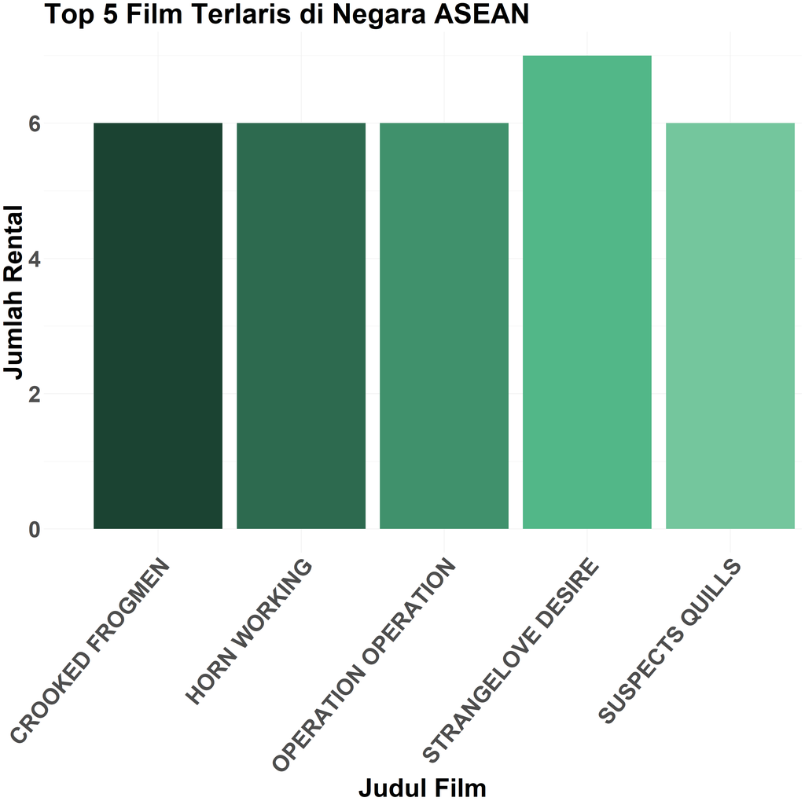

```r
ggplot(top5, aes(x = judul_film, y = total_rental, fill = judul_film)) +
  geom_bar(stat = "identity") +
  scale_x_discrete(expand = expansion(add = c(0.8, 0.5))) +
  scale_fill_manual(values =c("#1b4332", "#2d6a4f", "#40916c"
                              ,"#52b788", "#74c69d")) +
  labs(title = "Top 5 Film Terlaris di Negara ASEAN ",
       x = "Judul Film",
       y = "Jumlah Rental") +
  theme_minimal() +
  theme(
    axis.text.x = element_text(angle = 50, hjust = 1,vjust = 1, family = "Sans", size = 40, face = "bold"),
    axis.text.y = element_text(family = "Sans", size = 40, face ="bold"),
    plot.title = element_text(size = 50, face = "bold"),
    axis.title.x = element_text(size = 46, face = "bold"),
    axis.title.y = element_text(size = 46, face = "bold"),
    legend.position = "none")
```

### Diagaram batang genre film favourite seluruh negara ASEAN berdasarkan jumlah rental

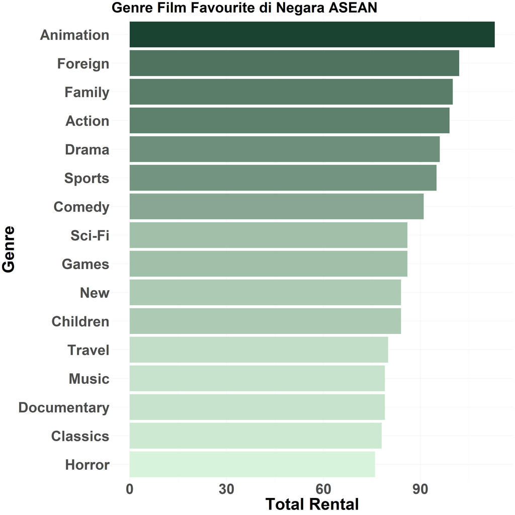

```r
ggplot(datagenre, aes(x = reorder(Genre, Total_Rental), y = Total_Rental, fill = Total_Rental)) +
  geom_bar(stat = "identity")+
  scale_fill_gradient(low = "#d8f3dc", high = "#1b4332") +
  coord_flip() +
  labs(title = "Genre Film Favourite di Negara ASEAN",
       x = "Genre",
       y = "Total Rental") +
  theme_minimal()+
  theme(
    axis.text.x = element_text(family = "Sans", size = 40, face = "bold"),
    axis.text.y = element_text(family = "Sans", size = 40, face ="bold"),
    plot.title = element_text(size = 40, face = "bold"),
    axis.title.x = element_text(size = 46, face = "bold"),
    axis.title.y = element_text(size = 46, face = "bold"),
    legend.position = "none")
```

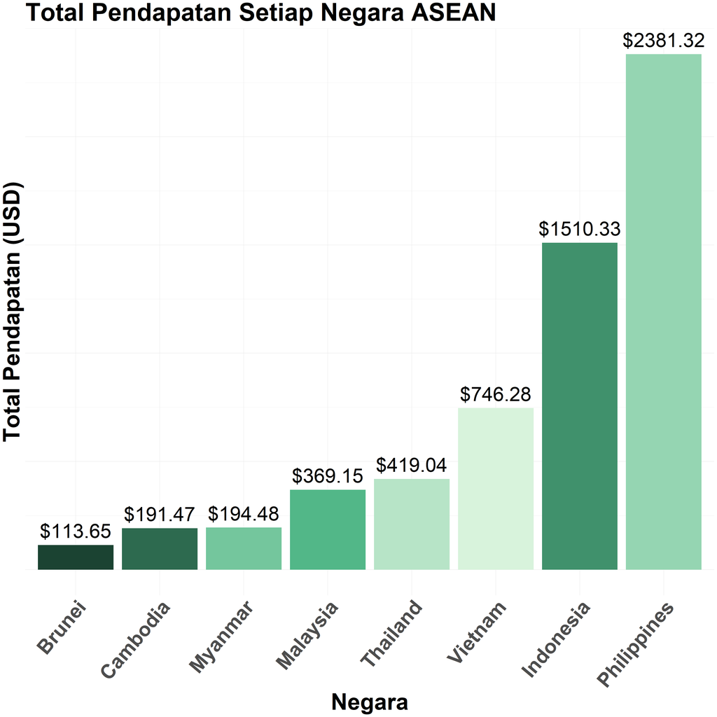

```r
ggplot(datapendapatan, aes(x = reorder(country, total_Pendapatan), y = total_Pendapatan, fill = country)) +
  geom_bar(stat = "identity") +
  geom_text(aes(label = paste0("$", total_Pendapatan)), size=14, vjust= -0.5)+
  scale_fill_manual(values =c("#1b4332", "#2d6a4f", "#40916c",
                              "#52b788", "#74c69d", "#95d5b2", "#b7e4c7", "#d8f3dc")) +
  labs(title = "Total Pendapatan Setiap Negara ASEAN",
       x = "Negara",
       y = "Total Pendapatan (USD)") +
  theme_minimal() +
  theme(
    axis.text.x = element_text(angle = 50, hjust = 1,vjust = 1, family = "Sans", size = 40, face = "bold"),
    axis.text.y = element_blank(),
    plot.title = element_text(size = 50, face = "bold"),
    axis.title.x = element_text(size = 46, face = "bold"),
    axis.title.y = element_text(size = 46, face = "bold"),
    legend.position = "none")
```

### Tabel Performa toko di wilayah ASEAN

Dalam perhitungan market share menggunakan rumus sebagai berikut:
$$\text{Market Share} = \frac{\text{Total Rental Negara}_i}{\sum_{i=1}^{n}
\text{Total Rental Negara}_i} \times 100\%$$

```r
knitr::kable(tabelperforma,
             caption = "Tabel Peforma Toko di Wilayah Asean",
             col.names = c("Negara", "Jumlah Pelanggan",  "Jumlah Transaksi", "Rata Rata Transaksi", "Market Share"),
             align = "lccccc")
```

Tabel Peforma Toko di Wilayah Asean

| Negara | Jumlah Pelanggan | Jumlah Transaksi | Rata Rata Transaksi | Market Share |
| --- | --- | --- | --- | --- |
| Philippines | 20 | 568 | 28.40 | 39.78% |
| Indonesia | 14 | 367 | 26.21 | 25.70% |
| Vietnam | 6 | 172 | 28.67 | 12.04% |
| Thailand | 3 | 96 | 32.00 | 6.72% |
| Malaysia | 3 | 85 | 28.33 | 5.95% |
| Cambodia | 2 | 53 | 26.50 | 3.71% |
| Myanmar | 2 | 52 | 26.00 | 3.64% |
| Brunei | 1 | 35 | 35.00 | 2.45% |

# Interpretasi Hasil

## Interpretasi diagram top 5 film terlaris di negara ASEAN

Berdasarkan diagram batang di atas, **STRANGELOVE DESIRE** merupakan film dengan jumlah rental tertinggi di kawasan ASEAN dengan total **7 rental**, sementara **CROOKED FROGMEN, HORN WORKING, OPERATION OPERATION,** dan **SUSPECTS QUILLS** masing-masing memiliki **6 rental**. Secara keseluruhan, perbedaan jumlah rental antar film tidak terlalu signifikan, berkisar antara 6–7 rental. Hal ini mengindikasikan bahwa preferensi penonton di kawasan ASEAN terhadap kelima film tersebut relatif merata dan tidak ada dominasi yang mencolok dari satu film tertentu.

## Interpretasi dari diagram genre favourite di negara ASEAN

Secara keseluruhan, dapat disimpulkan bahwa pelanggan di kawasan ASEAN memiliki preferensi yang cukup beragam terhadap berbagai genre film. Namun, genre **Animation** mendominasi sebagai genre favorit, kemungkinan karena daya tariknya yang universal dan dapat dinikmati oleh berbagai kalangan usia.

## Interpretasi idagram total pendapatan setiap negara yang tergabung dalam ASEAN

Berdasarkan diagram di atas, **Philippines** mencatatkan total pendapatan tertinggi di kawasan ASEAN dengan nilai mencapai sekitar **2.400**, jauh melampaui negara-negara lainnya. **Indonesia** berada di posisi kedua dengan total pendapatan sekitar **1.500**, diikuti **Vietnam** di posisi ketiga sekitar **750**. Sementara itu, **Brunei** menjadi negara dengan total pendapatan terendah, hanya sekitar **100**. Kesenjangan yang cukup besar antara Philippines dan negara-negara lainnya mengindikasikan bahwa Philippines merupakan pasar rental film terbesar dan paling potensial di kawasan ASEAN.

## Interpretasi tabel market share

Berdasarkan tabel hasil market share di atas, **Philippines** mendominasi pasar rental film di kawasan ASEAN dengan market share tertinggi sebesar **39.78%** dari total 568 rental, menjadikannya negara dengan kontribusi terbesar hampir setara dengan **2/5 dari keseluruhan pasar ASEAN**. **Indonesia** berada di posisi kedua dengan market share **25.70%** (367 rental), sehingga jika digabungkan, kedua negara ini menguasai lebih dari **65% pasar rental film ASEAN**.

**Vietnam** menempati posisi ketiga dengan kontribusi sebesar **12.04%**, sementara **Thailand** dan **Malaysia** masing-masing menyumbang **6.72%** dan **5.95%**. Di sisi lain, **Cambodia, Myanmar,** dan **Brunei** mencatatkan market share paling rendah, masing-masing hanya sebesar **3.71%, 3.64%,** dan **2.45%**, menunjukkan bahwa ketiga negara tersebut memiliki basis pelanggan yang masih sangat kecil dibandingkan negara ASEAN lainnya.

Secara keseluruhan, distribusi market share di kawasan ASEAN **tidak merata** dan cenderung terkonsentrasi pada dua negara besar yaitu Philippines dan Indonesia. Hal ini mengindikasikan adanya potensi pengembangan pasar yang masih sangat besar di negara-negara dengan market share rendah seperti Brunei, Myanmar, dan Cambodia.